# MOFA+: analysis of matching scRNA-seq and scATAC-seq data

### 5.6.2 Annotation to genes and GO terms

```r
library(ChIPseeker)
library(org.Hs.eg.db)
library(TxDb.Hsapiens.UCSC.hg38.knownGene)

# Add peak annotation to the regions (e.g. type of region, closest gene)
cisTopicObject <- annotateRegions(
  cisTopicObject,
  txdb = TxDb.Hsapiens.UCSC.hg38.knownGene,
  annoDb = 'org.Hs.eg.db'
)
```

```
## >> preparing features information...      2020-02-08 12:31:29
## >> identifying nearest features...        2020-02-08 12:31:32
## >> calculating distance from peak to TSS...   2020-02-08 12:31:33
## >> assigning genomic annotation...        2020-02-08 12:31:33
## >> adding gene annotation...          2020-02-08 12:32:14
## >> assigning chromosome lengths           2020-02-08 12:32:15
## >> done...                    2020-02-08 12:32:15
```

Heatmap containing the row normalised AUC values for the signatures in the topics

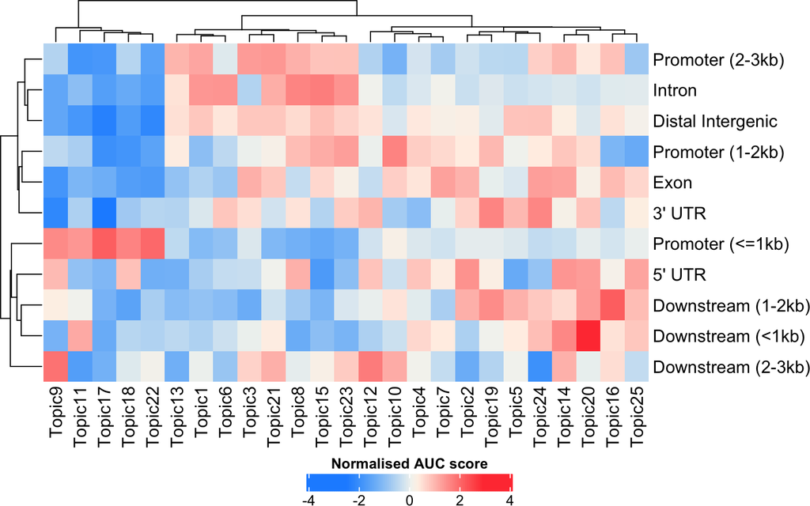

```r
signaturesHeatmap(
  cisTopicObject,
  selected.signatures = 'annotation'
)
```

### 5.6.3 Transcription Factor motif enrichment

```r
# cisTopicObject <- binarizedcisTopicsToCtx(cisTopicObject, genome='hg19')
#
# cisTopicObject <- scoredRegionsToCtx(cisTopicObject, genome='hg19')
#
# pathToFeather <- "hg19-regions-9species.all_regions.mc8nr.feather"
#
# cisTopicObject <- topicsRcisTarget(cisTopicObject, genome='hg19', pathToFeather, reduced_database=FALSE, nesThreshold=3, rocthr=0.005, maxRank=20000, nCores=5)
#
# Topic6_motif_enr <- cisTopicObject@binarized.RcisTarget[[6]]
#
# DT::datatable(Topic6_motif_enr[,-c("enrichedRegions", "TF_lowConf"), with=FALSE], escape = FALSE, filter="top", options=list(pageLength=5))
```

# 6 Conclusion

The count ATAC-seq matrix is too sparse to be used as input to MOFA. We recommend applying some pre-processing options to enrich the signal. A simple solution could be to aggregate peaks and summarise them. The second option, which we demonstrated here, is to use a signal extraction method such as cis-Topics, and then take their output as input to MOFA.